# Using microarray data to detect transcriptomic differences in the Alzheimer’s disease study GSE63061

In this analysis we are going to normalise then model microarray data to detect transcriptomic differences in genes using data from the Alzheimer’s disease study GSE63061.

```r
library(Biobase)
library(GEOquery)
library(limma)
library(sva)
```

## Normalise the data

Load the expression data, originally from https://www.ncbi.nlm.nih.gov/geo/query/acc.cgi?acc=GSE63061. Identify the probes and subject IDs.

```r
exprMat <- read.table(
  "./GSE63061_non-normalized.txt",
  header=TRUE,
  check.names=FALSE,
  as.is=TRUE
)

probesID <- exprMat[,1]
exprMat <- exprMat[,-1]
subsID <- colnames(exprMat)
exprMat <- as.matrix(exprMat)
```

Normalizes expression intensities so that the intensities (or log-ratios) have similar distributions across the arrays.

```r
exprNormdat <- normalizeBetweenArrays(exprMat, method="quantile")

exprNormdat[1:5,1:5]
```

```
##      7196843081_A 7196843081_B 7196843081_C 7196843081_D 7196843081_E
## [1,]     88.85335     85.77075     79.56997     86.27036     79.49330
## [2,]    104.12784     89.87732     89.50077     89.19369     89.35103
## [3,]     83.83454     82.31160     80.41856     83.18454     81.66031
## [4,]     82.41186     81.32358     79.46005     83.91753     81.84201
## [5,]     80.20232     84.24369     78.93711     84.66881     81.46302
```

To understand the effects of the normalisation, perform a log2 transformation on the normalised and non-normalised expression data, then concatenate and label the two datasets.

```r
L2exprMat <- log2(exprMat)
L2exprNorm <- log2(exprNormdat)

comp <- cbind(L2exprMat, L2exprNorm)
nsubs <- ncol(L2exprMat)

gr <- factor(rep(c("Not Normalized","Normalized"), each=nsubs))
```

Plot the distributions of each dataset.

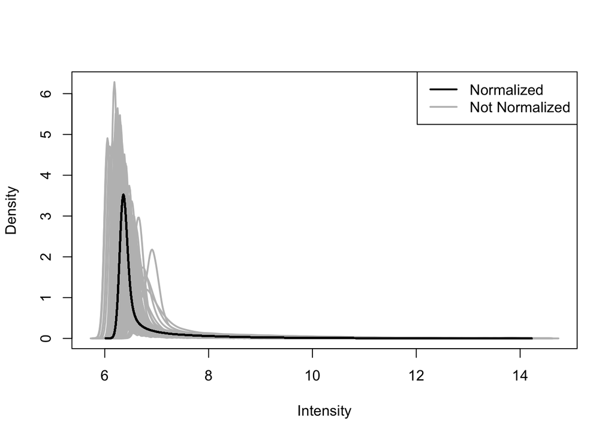

```r
plotDensities(comp, group=gr, col=c("black","grey"), legend="topright")
```

We can see that the non-normalised data is variable, but the normalised data has the same distribution across subjects.

Construct an ExpressionSet object with the normalized expression data.

```r
phenoDF <- data.frame(subsID, row.names=subsID)
phenodat <- AnnotatedDataFrame(data=phenoDF)

featureDF <- data.frame(probesID, row.names=probesID)
featureData <- AnnotatedDataFrame(data=featureDF)

exprNorm <- ExpressionSet(
  assayData=L2exprNorm,
  phenoData=phenodat,
  featureData=featureData
)

show(exprNorm)
```

```
## ExpressionSet (storageMode: lockedEnvironment)
## assayData: 47323 features, 388 samples
##   element names: exprs
## protocolData: none
## phenoData
##   sampleNames: 7196843081_A 7196843081_B ... 7348931013_L (388 total)
##   varLabels: subsID
##   varMetadata: labelDescription
## featureData
##   featureNames: ILMN_1762337 ILMN_2055271 ... ILMN_2137536 (47323
##     total)
##   fvarLabels: probesID
##   fvarMetadata: labelDescription
## experimentData: use 'experimentData(object)'
## Annotation:
```

Download the processed data for GSE63061, to compare it with exprNorm.

```r
gsm.expr <- getGEO("GSE63061", destdir = ".")
```

```
## Found 1 file(s)
```

```
## GSE63061_series_matrix.txt.gz
```

```
## Using locally cached version: ./GSE63061_series_matrix.txt.gz
```

```
## Using locally cached version of GPL10558 found here:
## ./GPL10558.soft
```

```r
gsm.expr <- gsm.expr[[1]]
show(gsm.expr)
```

```
## ExpressionSet (storageMode: lockedEnvironment)
## assayData: 32049 features, 388 samples
##   element names: exprs
## protocolData: none
## phenoData
##   sampleNames: GSM1539409 GSM1539410 ... GSM1539796 (388 total)
##   varLabels: title geo_accession ... tissue:ch1 (40 total)
##   varMetadata: labelDescription
## featureData
##   featureNames: ILMN_1343291 ILMN_1343295 ... ILMN_3311190 (32049
##     total)
##   fvarLabels: ID Species ... GB_ACC (30 total)
##   fvarMetadata: Column Description labelDescription
## experimentData: use 'experimentData(object)'
##   pubMedIds: 26343147
## Annotation: GPL10558
```

Identify the probes IDs in each dataset.

```r
probesIDsGEO <- as.character(fData(gsm.expr)$ID)
probesID <- as.character(fData(exprNorm)$probesID)
```

The normalized data, exprNorm, has not been filtered and contains more probes than gsm.expr. To compare the two dataset, filter to the common probes.

```r
selprobes <- probesID%in%probesIDsGEO
nselprobes <- sum(selprobes)

exprNorm.sel <- exprNorm[selprobes,]
```

Get the expression data from each dataset, then scale, concatenate, and label this data before plotting the intensity distributions.

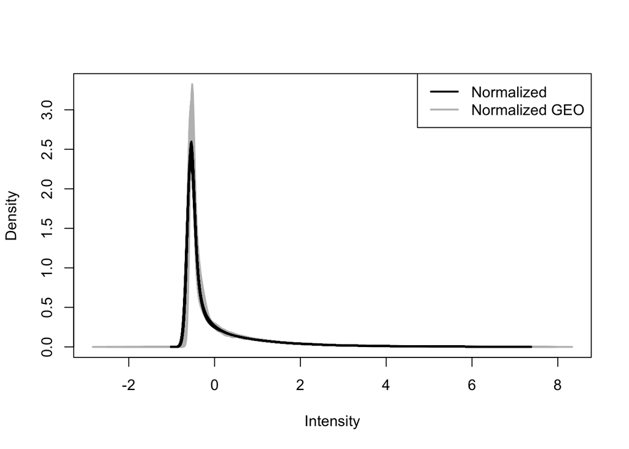

```r
exprGEO <- exprs(gsm.expr)
expr <- exprs(exprNorm.sel)

exprScaledGEO <- scale(exprGEO, scale=FALSE)
exprScaled <- scale(expr, scale=FALSE)

comp <- cbind(exprScaledGEO, exprScaled)

nsubs <- ncol(exprScaledGEO)
gr <- factor(rep(c("Normalized GEO","Normalized"), each=nsubs))

plotDensities(comp, group=gr, col=c("black", "grey"), legend="topright")
```

The distributions are very similar, so we can be confident that we have reproduced the normalization of this data as available in GEO.

## Modelling differential expression

Create variables for the phenotypes and statuses, then print the count of each status.

```r
pheno <- pData(phenoData(gsm.expr))
status <- pheno$characteristics_ch1
status <- gsub("status: ","", as.character(status))
fstatus <- factor(status)
levels(fstatus) <- gsub(" ", "", levels(fstatus))

table(fstatus)
```

```
## fstatus
##            AD borderlineMCI           CTL       CTLtoAD           MCI
##           139             3           134             1           109
##      MCItoCTL         OTHER
##             1             1
```

Create variables for the main two covariates: age and sex.

```r
age <- substr(pheno$characteristics_ch1.2, 6,7)
age <- as.numeric(age)
sex <- pheno$characteristics_ch1.3
```

Create two model matricies to measure the effect of the status variable. Then use the sva package to create two surrogate variables.

```r
phenodat <- data.frame(fstatus, age, sex)

mod0 <- model.matrix( ~ age + sex, data=phenodat)
mod <- model.matrix( ~ fstatus + age + sex, data=phenodat)

svobj <- sva(exprGEO, mod, mod0, n.sv=2)
```

```
## Number of significant surrogate variables is:  2
## Iteration (out of 5 ):1  2  3  4  5
```

Create a new model matrix using the previous features plus the surrogate variables.

```r
sv1 <- svobj$sv[,1]
sv2 <- svobj$sv[,2]
design <- model.matrix(~ 0 + fstatus + sex + age + sv1 + sv2)
colnames(design) <- c(levels(fstatus),"age","sex", "sva1","sva2")
```

Fit a linear model for each gene using the expression data.

```r
fit <- lmFit(exprGEO, design)
```

Create a contrast matrix using the design matrix from above. Next, compute estimated coefficients and standard errors for these contrasts. Finally, compute some statistics (t-statistics, moderated F-statistic, and log-odds) using eBayes.

```r
contrast.matrix <- makeContrasts(AD-CTL, MCI-CTL, AD-MCI, levels=design)

fit2 <- contrasts.fit(fit, contrast.matrix)
fit2 <- eBayes(fit2)
```

Identify which genes are significantly differentially expressed for each contrast and visualise these differences using a Venn diagram.

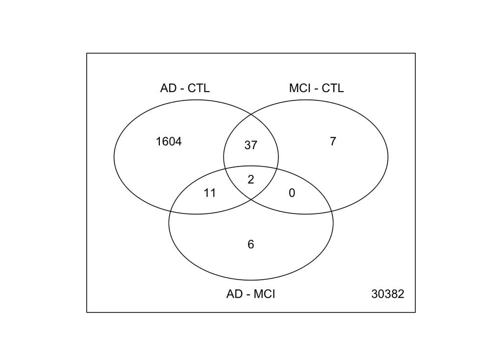

```r
results <- decideTests(fit2)
vennDiagram(results, cex=c(1, 0.7, 0.5))
```

The most probes with significant results are specific of the AD vs CTL contrast.

Print a dataframe showing the differentially expressed genes between AD and CTL with greatest statistical significance.

```r
tt <- topTable(fit2, coef=1, adjust="BH")

genesIDs <- as.character(fData(gsm.expr)$ILMN_Gene)
names(genesIDs) <- rownames(gsm.expr)

data.frame(genesIDsgenes=genesIDs[rownames(tt)], logFC=tt$logFC, pvalAdj=tt$adj.P.Val)
```

|  | genesIDsgenes | logFC | pvalAdj |
| --- | --- | --- | --- |
| ILMN_2189936 | RPL36AL | -0.3858575 | 9.095373e-14 |
| ILMN_1792528 | LOC401206 | -0.3558489 | 9.143345e-14 |
| ILMN_1746516 | RPS25 | -0.3551883 | 7.441007e-13 |
| ILMN_2189933 | RPL36AL | -0.3924215 | 6.199778e-12 |
| ILMN_1784286 | NDUFA1 | -0.4300590 | 6.199778e-12 |
| ILMN_1776104 | NDUFS5 | -0.3397758 | 1.369232e-11 |
| ILMN_1652073 | LOC653658 | -0.4164008 | 1.013183e-10 |
| ILMN_1732328 | LOC646200 | -0.3737275 | 6.251346e-10 |
| ILMN_2097421 | MRPL51 | -0.2316243 | 6.251346e-10 |
| ILMN_2048326 | RPS27A | -0.2350584 | 7.028370e-10 |

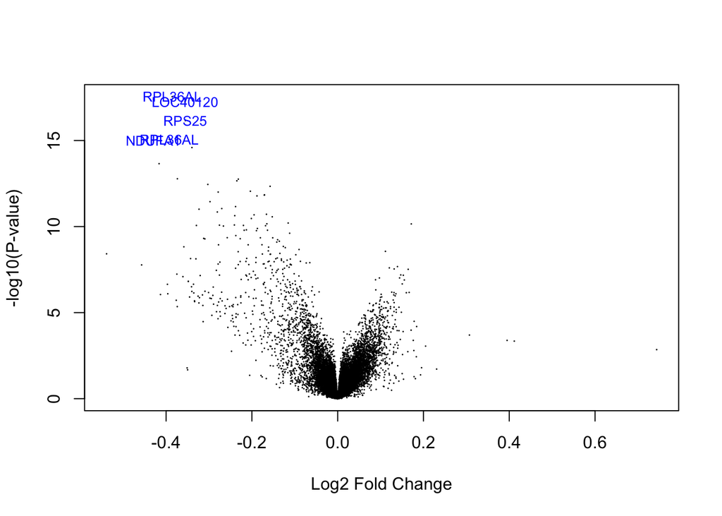

```r
volcanoplot(fit2, coef = 1, highlight=5, names=genesIDs, cex=0.2)
```